# Assignment-2

Author

Maria

# Data Wrangling

```r
library(tidyverse)
chs_individual <- read_csv("https://raw.githubusercontent.com/USCbiostats/data-science-data/master/01_chs/chs_individual.csv")
chs_regional <- read_csv("https://raw.githubusercontent.com/USCbiostats/data-science-data/master/01_chs/chs_regional.csv")
```

```r
chs <- merge(
 x = chs_individual,
 y = chs_regional,
 by = "townname"
)
```

## 1.

```r
#In the case of missing values, impute data using the average amongst individuals with the same values for the “male” and “hispanic” variables. For categorical variables, take the mode.

colSums(is.na(chs))
```

```
     townname           sid          male          race      hispanic
            0             0             0             0             0
       agepft        height        weight           bmi        asthma
           89            89            89            89            31
active_asthma father_asthma mother_asthma        wheeze      hayfever
            0           106            56            71           118
      allergy   educ_parent         smoke          pets      gasstove
           63            64            40             0            33
          fev           fvc          mmef     pm25_mass      pm25_so4
           95            97           106             0             0
     pm25_no3      pm25_nh4       pm25_oc       pm25_ec       pm25_om
            0             0             0             0             0
      pm10_oc       pm10_ec       pm10_tc        formic        acetic
            0             0             0             0             0
          hcl          hno3        o3_max         o3106         o3_24
            0             0             0             0             0
          no2          pm10       no_24hr      pm2_5_fr         iacid
            0             0           100           300             0
        oacid   total_acids           lon           lat
            0             0             0             0
```

```r
mode2 <- function(x){
     tab <- table(x)
     as.numeric(c(names(tab)[which.max(tab)]))
}

chs <- chs %>%
  group_by(male, hispanic) %>%
  mutate(
    agepft = coalesce(agepft, mean(agepft, na.rm = TRUE)),
    height = coalesce(height, mean(height, na.rm = TRUE)),
    weight = coalesce(weight, mean(weight, na.rm = TRUE)),
    bmi = coalesce(bmi, mean(bmi, na.rm = TRUE)),
    fev = coalesce(fev, mean(fev, na.rm = TRUE)),
    fvc = coalesce(fvc, mean(fvc, na.rm = TRUE)),
    mmef = coalesce(mmef, mean(mmef, na.rm=TRUE)),
    no_24hr = coalesce(no_24hr, mean(no_24hr, na.rm = TRUE)),
    pm2_5_fr = coalesce(pm2_5_fr, mean(pm2_5_fr, na.rm = TRUE))
  ) %>%
  mutate(
    asthma = coalesce(asthma, mode2(asthma)),
    father_asthma = coalesce(father_asthma, mode2(father_asthma)),
    mother_asthma = coalesce(mother_asthma, mode2(mother_asthma)),
    wheeze = coalesce(wheeze, mode2(wheeze)),
    hayfever = coalesce(hayfever, mode2(hayfever)),
    allergy = coalesce(allergy, mode2(allergy)),
    educ_parent = coalesce(educ_parent, mode2(educ_parent)),
    smoke = coalesce(smoke, mode2(smoke)),
    gasstove = coalesce(gasstove, mode2(gasstove))
  ) %>%
  collect() %>%
  ungroup()

colSums(is.na(chs))
```

```
     townname           sid          male          race      hispanic
            0             0             0             0             0
       agepft        height        weight           bmi        asthma
            0             0             0             0             0
active_asthma father_asthma mother_asthma        wheeze      hayfever
            0             0             0             0             0
      allergy   educ_parent         smoke          pets      gasstove
            0             0             0             0             0
          fev           fvc          mmef     pm25_mass      pm25_so4
            0             0             0             0             0
     pm25_no3      pm25_nh4       pm25_oc       pm25_ec       pm25_om
            0             0             0             0             0
      pm10_oc       pm10_ec       pm10_tc        formic        acetic
            0             0             0             0             0
          hcl          hno3        o3_max         o3106         o3_24
            0             0             0             0             0
          no2          pm10       no_24hr      pm2_5_fr         iacid
            0             0             0             0             0
        oacid   total_acids           lon           lat
            0             0             0             0
```

## 2.

```r
# Create a new categorical variable named “obesity_level” using the BMI measurement (underweight BMI<14; normal BMI 14-22; overweight BMI 22-24; obese BMI>24). To make sure the variable is rightly coded, create a summary table that contains the minimum BMI, maximum BMI, and the total number of observations per category.

chs <- chs %>%
  mutate(
    bmi_cat = cut(
      x = bmi,
      breaks = c(-Inf, 14, 22, 24, Inf),
      labels = c("underweight", "normal", "overweight", "obese")
    )
  )
any(is.na(chs$bmi_cat))
```

```
[1] FALSE
```

```r
chs %>%
  group_by(bmi_cat) %>%
  summarise(
    min_bmi = min(bmi),
    max_bmi = max(bmi),
    n = n()
  )
```

```
# A tibble: 4 × 4
  bmi_cat     min_bmi max_bmi     n
  <fct>         <dbl>   <dbl> <int>
1 underweight    11.3    14.0    35
2 normal         14.0    22.0   975
3 overweight     22.0    24.0    87
4 obese          24.0    41.3   103
```

## 3.

```r
# Create another categorical variable named “smoke_gas_exposure” that summarizes “Second Hand Smoke” and “Gas Stove.” The variable should have four categories in total.

chs <- chs %>%
  mutate(
    smoke_gas_exposure = case_when(
      smoke == 0 & gasstove == 0 ~ "none",
      smoke == 1 & gasstove == 0 ~ "smoke only",
      smoke == 0 & gasstove == 1 ~ "gas only",
      smoke == 1 & gasstove == 1 ~ "both"
    )
  )

any(is.na(chs$smoke_gas_exposure))
```

```
[1] FALSE
```

## 4.

```r
# Create four summary tables showing the average (or proportion, if binary) and sd of “Forced expiratory volume in 1 second (ml)” (an asthma indicator) by town, sex, obesity level, and “smoke_gas_exposure.”

chs %>%
  group_by(townname) %>%
  summarise(avg_fev = mean(fev), sd_fev = sd(fev))
```

```
# A tibble: 12 × 3
   townname      avg_fev sd_fev
   <chr>           <dbl>  <dbl>
 1 Alpine          2087.   291.
 2 Atascadero      2076.   324.
 3 Lake Elsinore   2039.   304.
 4 Lake Gregory    2085.   320.
 5 Lancaster       2003.   317.
 6 Lompoc          2034.   351.
 7 Long Beach      1986.   319.
 8 Mira Loma       1985.   325.
 9 Riverside       1990.   278.
10 San Dimas       2027.   319.
11 Santa Maria     2026.   312.
12 Upland          2024.   343.
```

```r
chs %>%
  group_by(male) %>%
  summarise(avg_fev = mean(fev), sd_fev = sd(fev))
```

```
# A tibble: 2 × 3
   male avg_fev sd_fev
  <dbl>   <dbl>  <dbl>
1     0   1959.   312.
2     1   2104.   308.
```

```r
chs %>%
  group_by(bmi_cat) %>%
  summarise(avg_fev = mean(fev), sd_fev = sd(fev))
```

```
# A tibble: 4 × 3
  bmi_cat     avg_fev sd_fev
  <fct>         <dbl>  <dbl>
1 underweight   1698.   303.
2 normal        2000.   295.
3 overweight    2224.   317.
4 obese         2266.   325.
```

```r
chs %>%
  group_by(smoke_gas_exposure) %>%
  summarise(avg_fev = mean(fev), sd_fev = sd(fev))
```

```
# A tibble: 4 × 3
  smoke_gas_exposure avg_fev sd_fev
  <chr>                <dbl>  <dbl>
1 both                 2025.   301.
2 gas only             2023.   319.
3 none                 2057.   329.
4 smoke only           2056.   296.
```

# Looking at the Data (EDA)

### Primary questions of interest:

1. What is the association between BMI and FEV (forced expiratory volume)?
2. What is the association between smoke and gas exposure and FEV?
3. What is the association between PM2.5 exposure and FEV?

### EDA Checklist:

- **Formulate a question - done above**
- **Read in the data - done above**
- **Check the dimensions and headers and footers of the data**

```r
# Check the dimenstions and headers and footers of the data
dim(chs)
```

```
[1] 1200   51
```

```r
head(chs)
```

```
# A tibble: 6 × 51
  townname   sid  male race  hispanic agepft height weight   bmi asthma
  <chr>    <dbl> <dbl> <chr>    <dbl>  <dbl>  <dbl>  <dbl> <dbl>  <dbl>
1 Alpine     841     1 W            1  10.5     150     78  15.8      0
2 Alpine     835     0 W            0  10.1     143     69  15.3      0
3 Alpine     838     0 O            1   9.49    133     62  15.9      0
4 Alpine     840     0 W            0   9.97    146     78  16.6      0
5 Alpine     865     0 W            0  10.0     162    140  24.2      1
6 Alpine     867     0 W            1   9.96    141     94  21.5      0
# ℹ 41 more variables: active_asthma <dbl>, father_asthma <dbl>,
#   mother_asthma <dbl>, wheeze <dbl>, hayfever <dbl>, allergy <dbl>,
#   educ_parent <dbl>, smoke <dbl>, pets <dbl>, gasstove <dbl>, fev <dbl>,
#   fvc <dbl>, mmef <dbl>, pm25_mass <dbl>, pm25_so4 <dbl>, pm25_no3 <dbl>,
#   pm25_nh4 <dbl>, pm25_oc <dbl>, pm25_ec <dbl>, pm25_om <dbl>, pm10_oc <dbl>,
#   pm10_ec <dbl>, pm10_tc <dbl>, formic <dbl>, acetic <dbl>, hcl <dbl>,
#   hno3 <dbl>, o3_max <dbl>, o3106 <dbl>, o3_24 <dbl>, no2 <dbl>, …
```

```r
tail(chs)
```

```
# A tibble: 6 × 51
  townname   sid  male race  hispanic agepft height weight   bmi asthma
  <chr>    <dbl> <dbl> <chr>    <dbl>  <dbl>  <dbl>  <dbl> <dbl>  <dbl>
1 Upland    1866     0 O            1   9.81   139    60    14.1      0
2 Upland    1867     0 M            1   9.62   140    71    16.5      0
3 Upland    2033     0 M            0  10.1    130    67    18.0      0
4 Upland    2031     1 W            0   9.80   135    83    20.7      0
5 Upland    2032     1 W            0   9.55   137    59    14.3      0
6 Upland    2053     0 W            0   9.85   139.   77.4  18.1      0
# ℹ 41 more variables: active_asthma <dbl>, father_asthma <dbl>,
#   mother_asthma <dbl>, wheeze <dbl>, hayfever <dbl>, allergy <dbl>,
#   educ_parent <dbl>, smoke <dbl>, pets <dbl>, gasstove <dbl>, fev <dbl>,
#   fvc <dbl>, mmef <dbl>, pm25_mass <dbl>, pm25_so4 <dbl>, pm25_no3 <dbl>,
#   pm25_nh4 <dbl>, pm25_oc <dbl>, pm25_ec <dbl>, pm25_om <dbl>, pm10_oc <dbl>,
#   pm10_ec <dbl>, pm10_tc <dbl>, formic <dbl>, acetic <dbl>, hcl <dbl>,
#   hno3 <dbl>, o3_max <dbl>, o3106 <dbl>, o3_24 <dbl>, no2 <dbl>, …
```

- **Check the variable types in the data**

```r
str(chs)
```

```
tibble [1,200 × 51] (S3: tbl_df/tbl/data.frame)
 $ townname          : chr [1:1200] "Alpine" "Alpine" "Alpine" "Alpine" ...
 $ sid               : num [1:1200] 841 835 838 840 865 867 842 839 844 847 ...
 $ male              : num [1:1200] 1 0 0 0 0 0 1 0 1 1 ...
 $ race              : chr [1:1200] "W" "W" "O" "W" ...
 $ hispanic          : num [1:1200] 1 0 1 0 0 1 1 1 1 0 ...
 $ agepft            : num [1:1200] 10.55 10.1 9.49 9.97 10.04 ...
 $ height            : num [1:1200] 150 143 133 146 162 141 139 142 143 137 ...
 $ weight            : num [1:1200] 78 69 62 78 140 94 65 86 65 69 ...
 $ bmi               : num [1:1200] 15.8 15.3 15.9 16.6 24.2 ...
 $ asthma            : num [1:1200] 0 0 0 0 1 0 0 0 0 0 ...
 $ active_asthma     : num [1:1200] 0 0 0 0 1 0 0 0 0 0 ...
 $ father_asthma     : num [1:1200] 0 0 0 0 0 0 0 0 0 0 ...
 $ mother_asthma     : num [1:1200] 0 0 0 0 0 0 0 1 0 0 ...
 $ wheeze            : num [1:1200] 0 0 0 0 1 0 1 1 0 0 ...
```

[output cut: 37 more lines]

- **Take a closer look at some/all of the variables**

```r
any(is.na(chs))
```

```
[1] FALSE
```

```r
chs %>%
  select(sid) %>% unique %>% nrow
```

```
[1] 1200
```

```r
table(chs$bmi_cat)
```

```
underweight      normal  overweight       obese
         35         975          87         103
```

```r
summary(chs$bmi)
```

```
   Min. 1st Qu.  Median    Mean 3rd Qu.    Max.
  11.30   15.96   17.81   18.50   19.99   41.27
```

```r
table(chs$smoke_gas_exposure)
```

```
      both   gas only       none smoke only
       154        791        219         36
```

```r
summary(chs$fev)
```

```
   Min. 1st Qu.  Median    Mean 3rd Qu.    Max.
  984.8  1827.6  2016.4  2030.1  2223.6  3323.7
```

```r
summary(chs$pm25_mass)
```

```
   Min. 1st Qu.  Median    Mean 3rd Qu.    Max.
  5.960   7.615  10.545  14.362  20.988  29.970
```

- **Validate with an external source:**
  - There are no missing values and we can see that there are no duplicate subject IDs. None of the BMI values jump out as implausible and the median BMI value falls within the “normal” BMI category, which is the category the majority of the children fall into. Based on a quick Google search, FEV1 predicted values depend on age and height and typical predicted values seem to fall within the 1 to 3 liter ranges, so the values listed in the summary table seem plausible. According to the EPA’s National Ambient Air Quality Standards (NAAQS) for PM, the average primary (health-based) annual and 24-hour PM2.5 standards are 12 ug/m3 and 35 ug/m3, respectively. The PM2.5 mass concentration values listed in the summary table do not seem implausible based on that information.
- **Exploratory graphs**

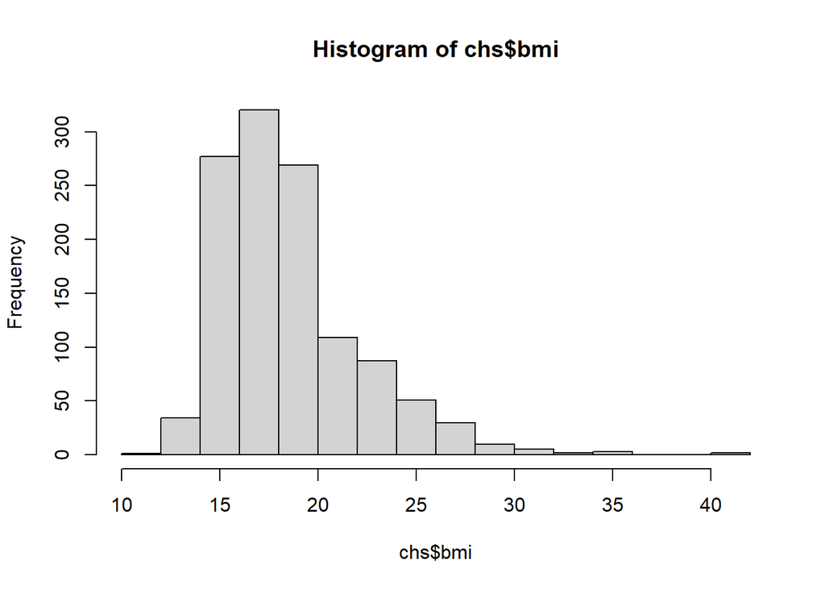

```r
hist(chs$bmi)
```

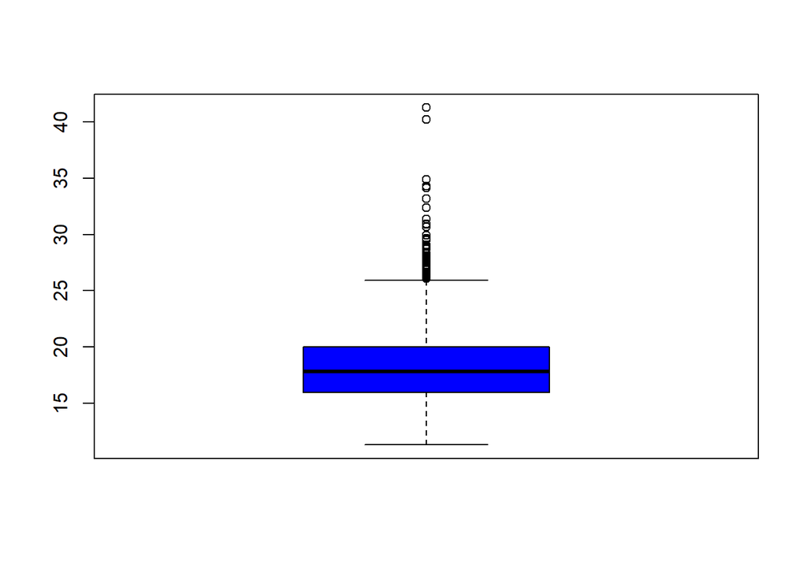

```r
boxplot(chs$bmi, col = "blue")
```

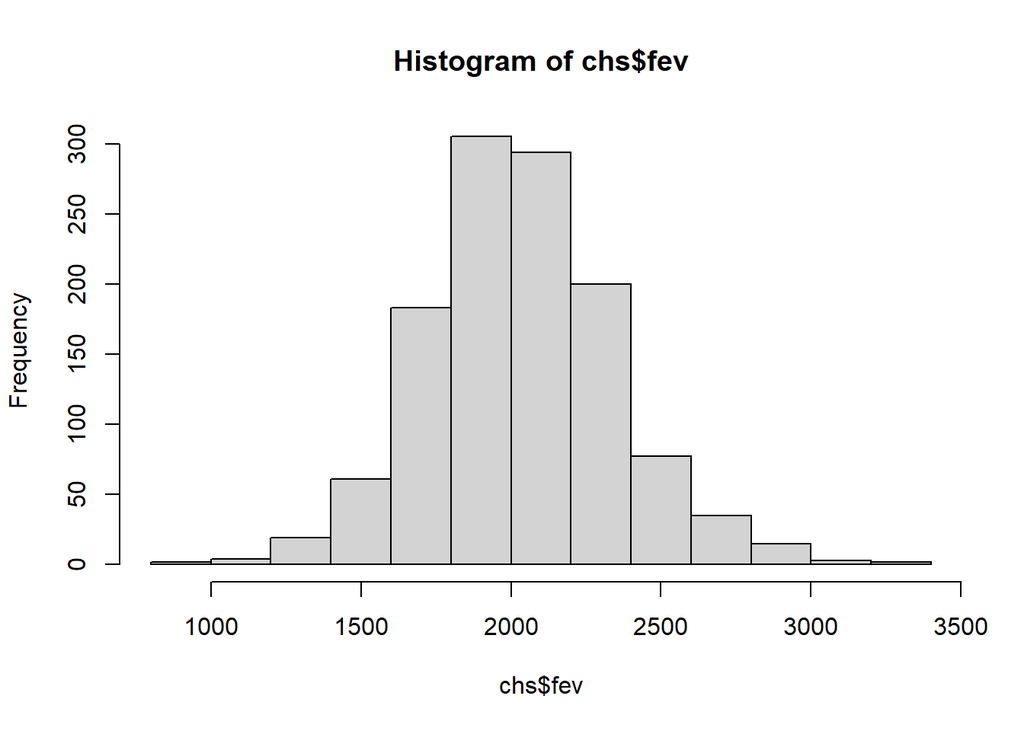

```r
hist(chs$fev)
```

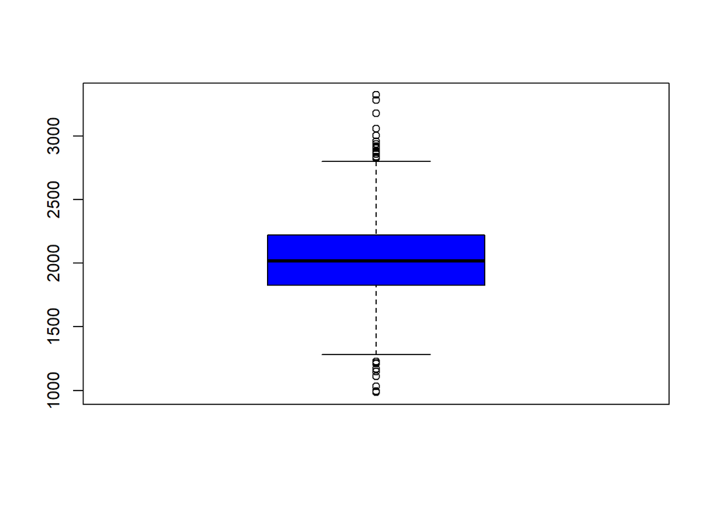

```r
boxplot(chs$fev, col = "blue")
```

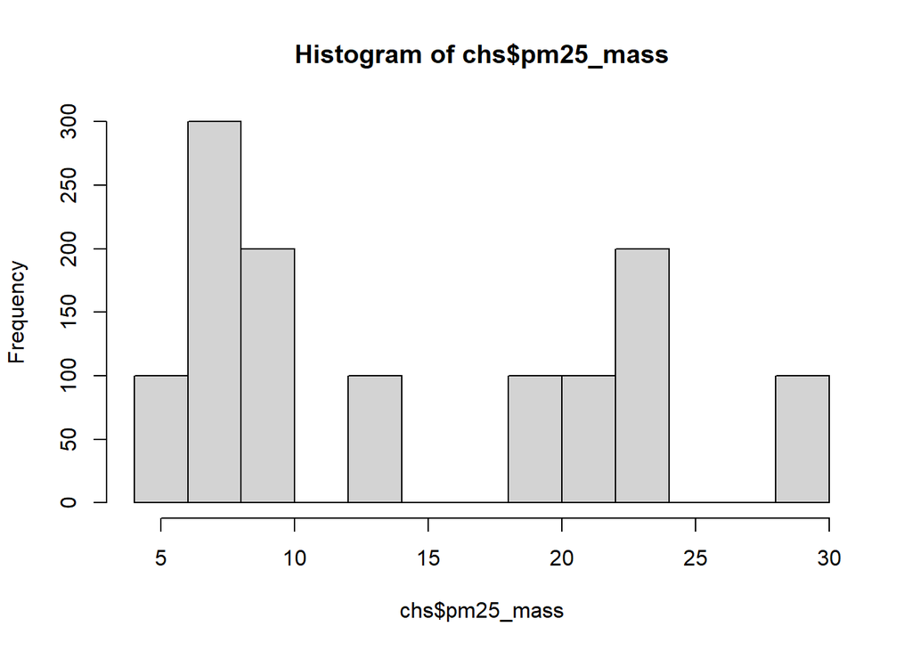

```r
hist(chs$pm25_mass)
```

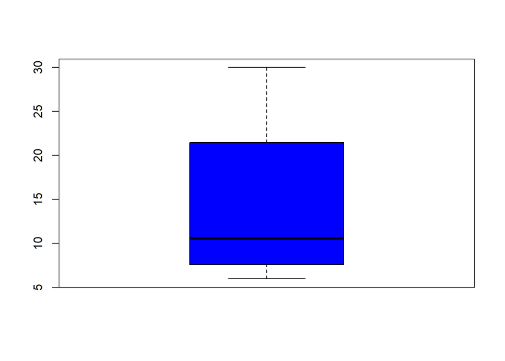

```r
boxplot(chs$pm25_mass, col = "blue")
```

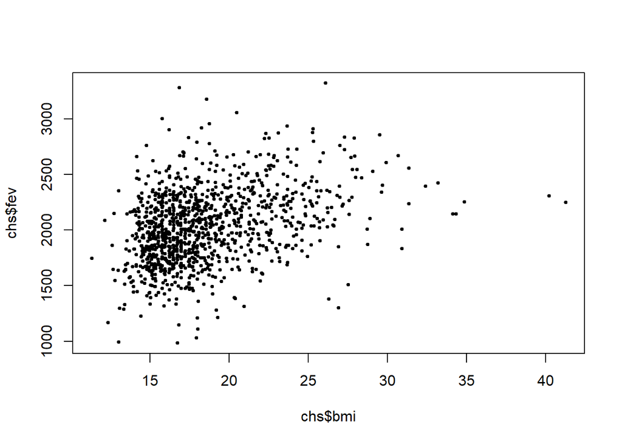

```r
plot(chs$bmi, chs$fev, pch=19, cex=0.5)
```

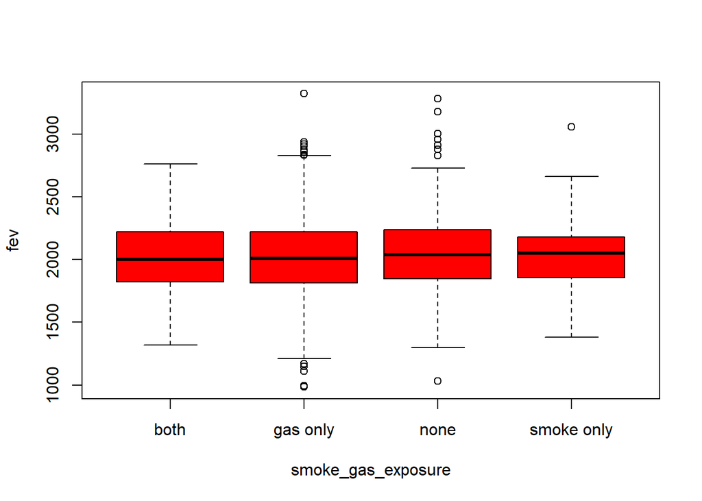

```r
boxplot(fev ~ smoke_gas_exposure, data = chs, col = "red")
```

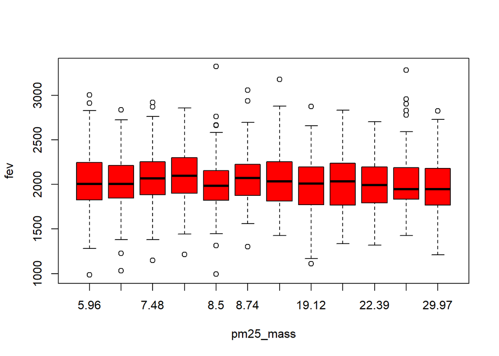

```r
boxplot(fev ~ pm25_mass, data = chs, col = "red")
```

# Visualization

#### Facet plot showing scatterplots with regression lines of BMI vs FEV by "townname"

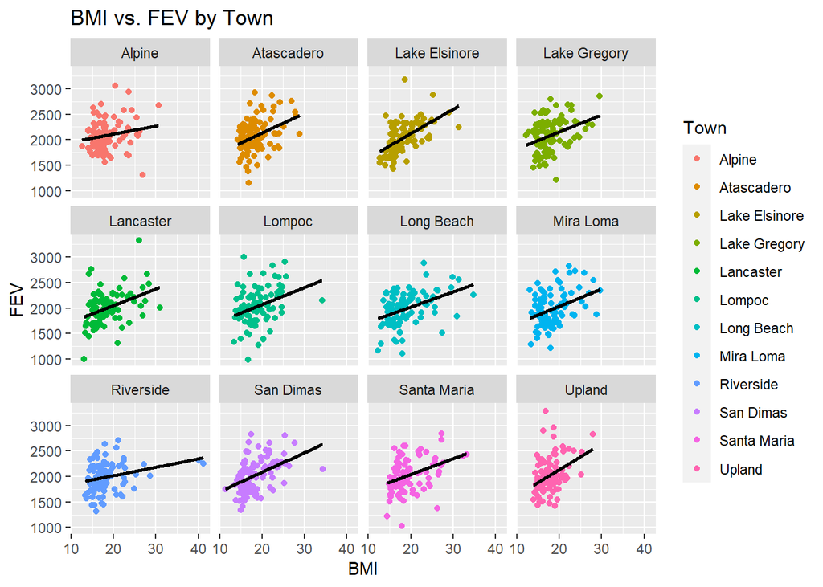

```r
chs %>%
  ggplot(mapping = aes(x = bmi, y = fev, color = townname)) +
  geom_point() +
  geom_smooth(method = lm, se = FALSE, col = "black") +
  facet_wrap(~ townname, nrow = 3) +
  labs(
    title = "BMI vs. FEV by Town",
    x = "BMI",
    y = "FEV",
    color = "Town")
```

#### Stacked histograms of FEV by BMI category and FEV by smoke/gas exposure. Use different color schemes than the ggplot default

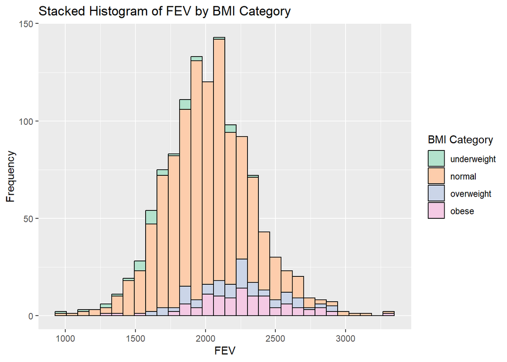

```r
chs %>%
  ggplot(mapping = aes(x = fev, fill = bmi_cat)) +
  geom_histogram(bins = 30, position = "stack", color = "black") +
  scale_fill_brewer(palette = "Pastel2") +
    labs(
    title = "Stacked Histogram of FEV by BMI Category",
    x = "FEV",
    y = "Frequency",
    fill = "BMI Category"
  )
```

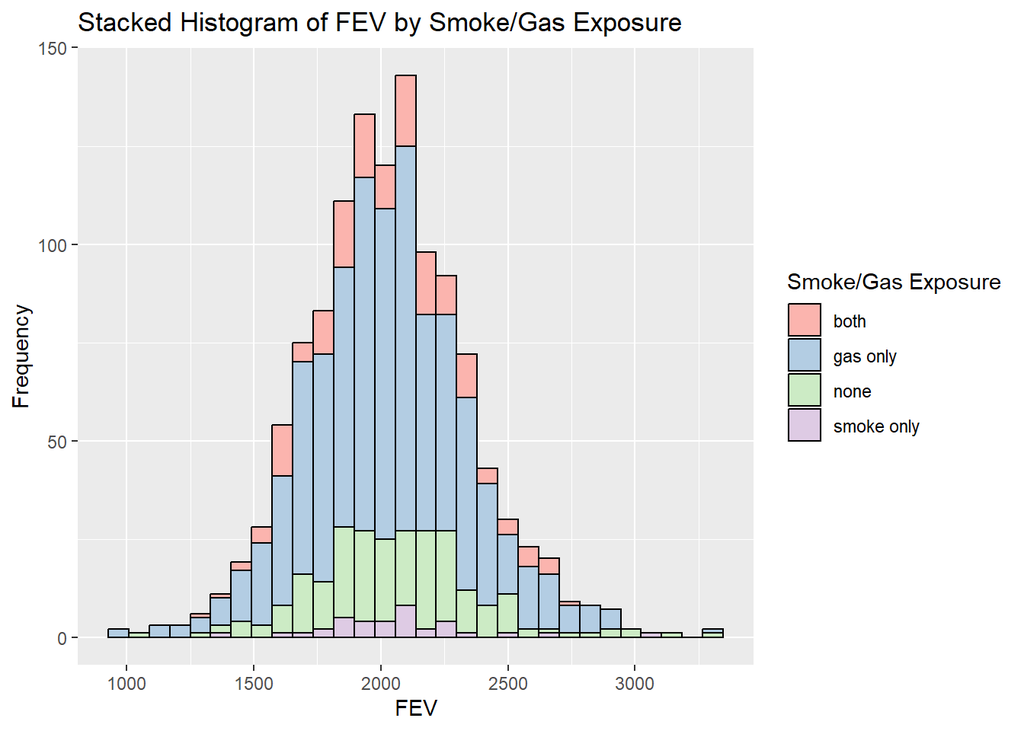

```r
chs %>%
  ggplot(mapping = aes(x = fev, fill = smoke_gas_exposure)) +
  geom_histogram(bins = 30, position = "stack", color = "black") +
  scale_fill_brewer(palette = "Pastel1") +
    labs(
    title = "Stacked Histogram of FEV by Smoke/Gas Exposure",
    x = "FEV",
    y = "Frequency",
    fill = "Smoke/Gas Exposure"
  )
```

#### Bar chart of BMI by smoke/gas exposure.

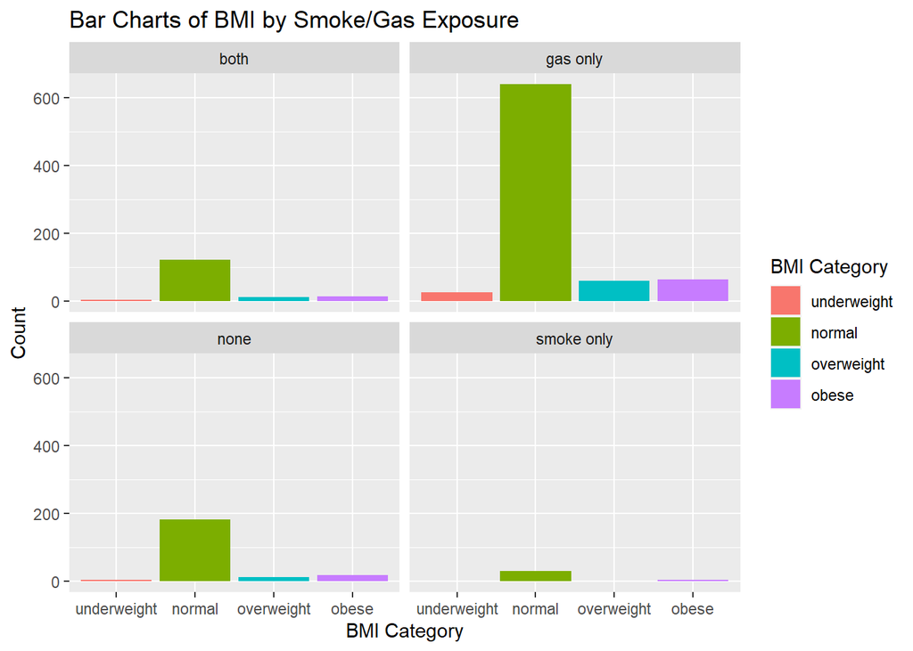

```r
chs %>%
  ggplot(mapping = aes(x = bmi_cat, fill = bmi_cat))+
  geom_bar() +
  facet_wrap(~ smoke_gas_exposure, nrow = 2) +
  labs(
    title = "Bar Charts of BMI by Smoke/Gas Exposure",
    x = "BMI Category",
    y = "Count",
    fill = "BMI Category"
  )
```

#### Statistical summary graphs of FEV by BMI and FEV by smoke/gas exposure category

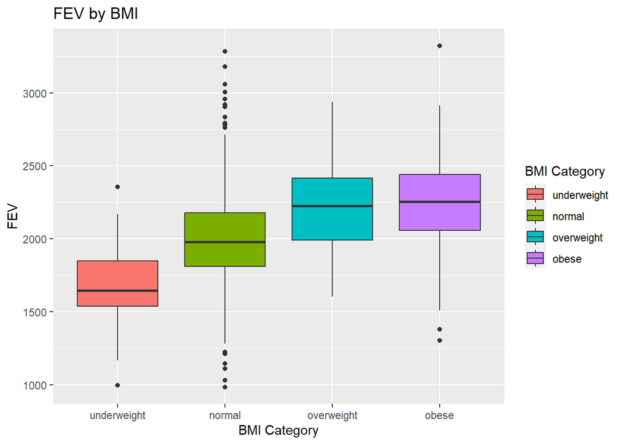

```r
chs %>%
  ggplot(aes(x = bmi_cat, y = fev, fill = bmi_cat)) +
  geom_boxplot() +
  labs(
    title = "FEV by BMI",
    x = "BMI Category",
    y = "FEV",
    fill = "BMI Category"
  )
```

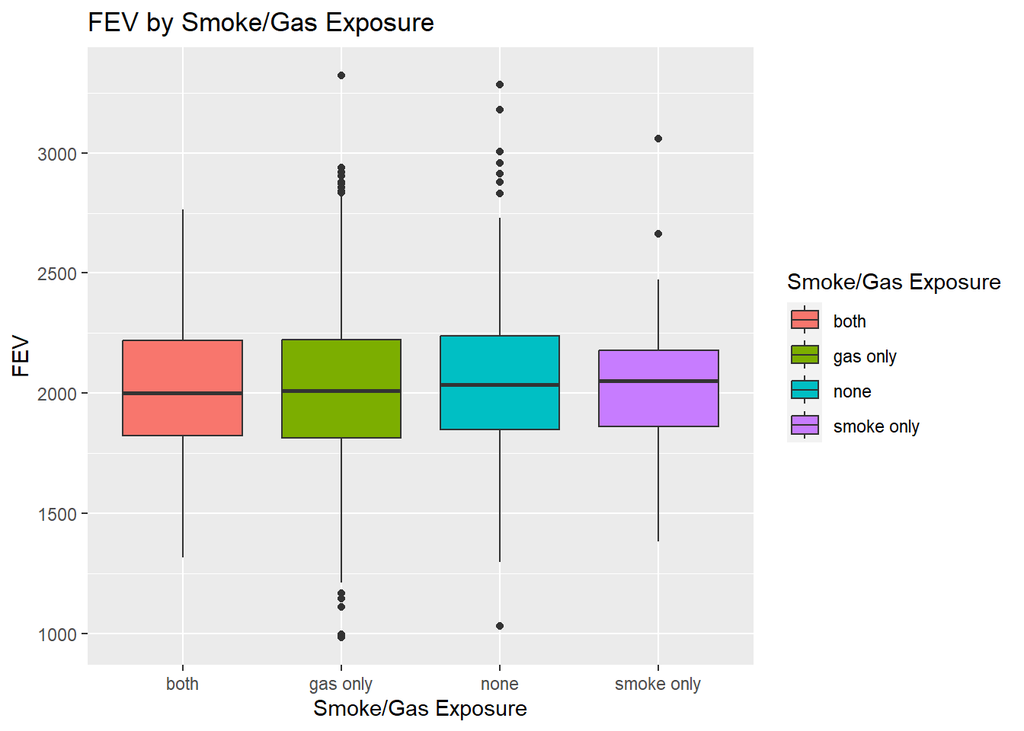

```r
chs %>%
  ggplot(aes(x = smoke_gas_exposure, y = fev, fill = smoke_gas_exposure)) +
  geom_boxplot() +
  labs(
    title = "FEV by Smoke/Gas Exposure",
    x = "Smoke/Gas Exposure",
    y = "FEV",
    fill = "Smoke/Gas Exposure"
  )
```

#### A leaflet map showing the concentrations of PM2.5 mass in each of the CHS communities.

```r
library(leaflet)

leaflet(chs) %>%
  addProviderTiles('CartoDB.Positron') %>%
  addCircles(
    lat = ~lat,
    lng = ~lon,
    label = ~paste0(round(pm25_mass,2), 'ug/m3'),
    color = "black",
    radius = 400,
    opacity = 1,
    fillOpacity = 1)
```

[interactive chart not shown]

#### Choose a visualization to examine whether PM2.5 mass is associated with FEV

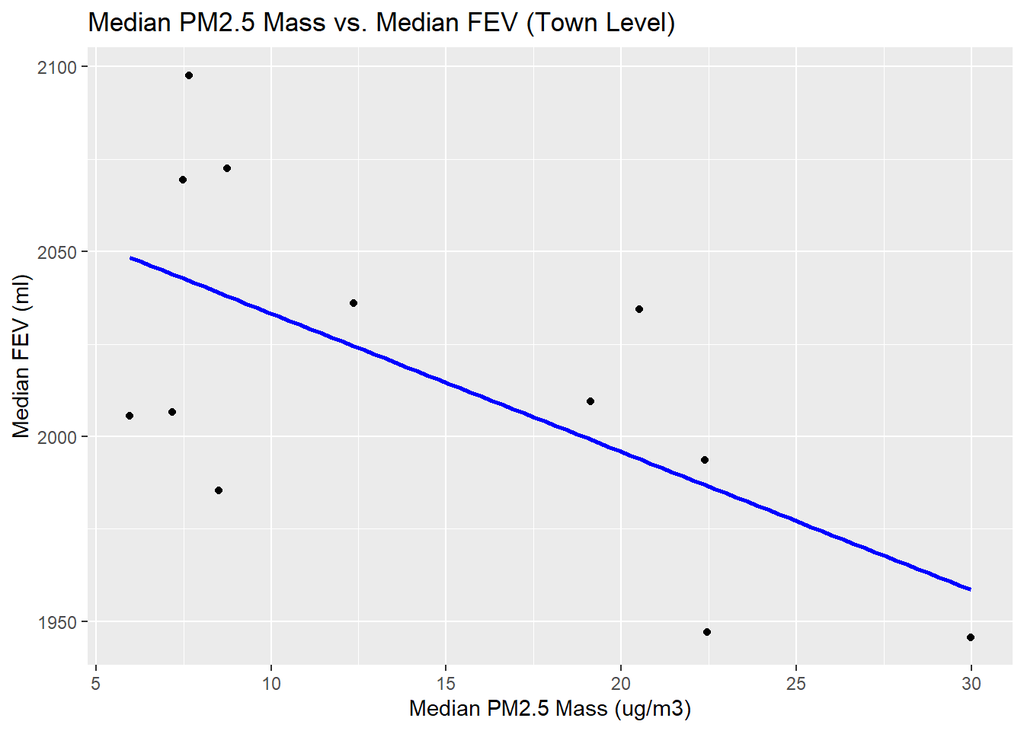

```r
chs %>%
  group_by(townname) %>%
  summarise(med_pm25 = median(pm25_mass), med_fev = median(fev)) %>%
  ggplot(mapping = aes(x = med_pm25, y = med_fev)) +
  geom_point() +
  geom_smooth(method = "lm", se = FALSE, color = "blue") +
  labs(title = "Median PM2.5 Mass vs. Median FEV (Town Level)",
    x = "Median PM2.5 Mass (ug/m3)",
    y = "Median FEV (ml)"
  )
```